# Clustering of transcriptional profile based on cell cycle genes

Kushal K Dey, Joyce Hsiao

September 17, 2015

## Goal

```r
library(data.table)
library(maptpx)
library(gplots)
library(philentropy)
library(dplyr)
library(edgeR)
library(tsne)
library(qtlcharts)
library(ggplot2)
```

## Prepare data

Import raw counts.

```r
reads <- data.frame(fread('../data/reads.txt'),row.names=1);
molecules <-  data.frame(fread('../data/molecules.txt'),row.names=1);
```

Import quality single cell index.

```r
quality_single_cells <- scan("../data/quality-single-cells.txt",
                             what = "character")
anno <- data.frame(fread('../data/annotation.txt'));
```

```r
molecules <- molecules[, grepl("bulk", colnames(molecules)) |
                         colnames(molecules) %in% quality_single_cells]
anno <- anno[anno$well == "bulk" | anno$sample_id %in% quality_single_cells, ]
stopifnot(ncol(molecules) == nrow(anno),
          colnames(molecules) == anno$sample_id)

reads <- reads[, grepl("bulk", colnames(reads)) |
                         colnames(reads) %in% quality_single_cells]
stopifnot(ncol(reads) == nrow(anno),
          colnames(reads) == anno$sample_id)
```

Exclude genes with no mapped reads across the single cell samples.

```r
expressed <- rowSums(molecules[, anno$well == "bulk"]) > 0 &
             rowSums(molecules[, anno$well != "bulk"]) > 0
molecules <- molecules[expressed, ]

expressed <- rowSums(reads[, anno$well == "bulk"]) > 0 &
             rowSums(reads[, anno$well != "bulk"]) > 0
reads <- reads[expressed, ]

molecules_single <- molecules %>% select(-contains("bulk"))
reads_single <- reads %>% select(-contains("bulk"))
```

Remove genes with max molecule numer larger than 1024

```r
molecules_single <- molecules_single[apply(molecules_single,1,max) < 1024,];
```

## Cell-cycle genes

Now we import the list of marker gene for cell cycle information.

```r
cell_cycle_genes <- read.table("../data/cellcyclegenes.txt", header = TRUE, sep="\t")
```

Now we draw a list of marker genes that have cell cycle information.

```r
## create 5 lists of 5 phases (de-level and then remove "")
cell_cycle_genes_list <- lapply(1:5,function(x){
                                    temp <- as.character(cell_cycle_genes[,x])
                                    temp[temp!=""]
                            })
```

We extract those columns (genes) that match with the cell-cycle genes list.

```r
labs <- unique(unlist(lapply(1:5, function(k) X =
                                 match(cell_cycle_genes_list[[k]],
                                       rownames(molecules_single)))) )
labs <-  labs[!is.na(labs)]
molecules_single_cell_cycle <- molecules_single[labs, ]
```

We have now extracted the data for the cell cycle genes only. Based on these cell cycle genes, we assign each cell to one of the phase scores.

```r
ans <-
sapply(cell_cycle_genes_list,function(xx){
  #### create table of each phase
  reads_single_phase <- reads_single[rownames(reads_single) %in% unlist(xx) ,]
  #### add average expression of all genes in the phase
  combined_matrix <- rbind(reads_single_phase,average=apply(reads_single_phase,2,mean))
  #### use transpose to compute cor matrix
  cor_matrix <- cor(t(combined_matrix))
  #### take the numbers
  cor_vector <- cor_matrix[,dim(cor_matrix)[1]]
  #### restrict to correlation >= 0.3
  reads_single_phase_restricted <- reads_single_phase[rownames(reads_single_phase) %in% names(cor_vector[cor_vector >= 0.3]),]
  #### apply normalization to reads
  norm_factors_single <- calcNormFactors(reads_single_phase_restricted, method = "TMM")
  reads_single_cpm <- cpm(reads_single_phase_restricted, log = TRUE,
                            lib.size = colSums(reads_single) * norm_factors_single)
  #### output the phase specific scores (mean of normalized expression levels in the phase)
  apply(reads_single_cpm,2,mean)

})

#### normalization function
flexible_normalization <- function(data_in,by_row=TRUE){
  if(by_row){
    row_mean <- apply(data_in,1,mean)
    row_sd   <- apply(data_in,1,sd)
    output <- data_in
    for(i in 1:dim(data_in)[1]){
      output[i,] <- (data_in[i,] - row_mean[i])/row_sd[i]
    }
  }
  #### if by column
  if(!by_row){
    col_mean <- apply(data_in,2,mean)
    col_sd   <- apply(data_in,2,sd)
    output <- data_in
    for(i in 1:dim(data_in)[2]){
      output[,i] <- (data_in[,i] - col_mean[i])/col_sd[i]
    }
  }
  output
}

#### apply the normalization function
## first normalized for each phase
ans_normed <- flexible_normalization(ans,by_row=FALSE)
## then normalized of each cell
ans_normed_normed <- flexible_normalization(ans_normed,by_row=TRUE)

cell_phase <- apply(ans_normed_normed,1,function(x) colnames(cell_cycle_genes)[which.max(x)])
assign_cell_phase <- data.frame(cell_phase)
```

The cell phase vector is given by

```r
cell_phase_vector <- as.vector(as.matrix(assign_cell_phase))
cell_phase_vector <- factor(cell_phase_vector,
                            levels = c("G1.S", "S", "G2.M", "M", "M.G1"))
```

## Maximum normalized value of cell cycle scores

### Admixture model (topic model)

We now fit an admixture model (topic model) on the molecule count data comprising of only the cell cycle genes.

```r
clust_vec <- 2:7
if(file.exists("../rdas/clustering-cell-cycle-genes/topics-maximum-normalized.rda")) {
    load("../rdas/clustering-cell-cycle-genes/topics-maximum-normalized.rda")
} else {
    topics_list <- lapply(clust_vec, function(per_clust) {
        topics(t(molecules_single_cell_cycle), K = per_clust, tol = 0.005)
        })
    names(topics_list) <- paste0("clust",clust_vec)
    save(topics_list,
         file = "../rdas/clustering-cell-cycle-genes/topics-maximum-normalized.rda")
}
```

Making structure plots.

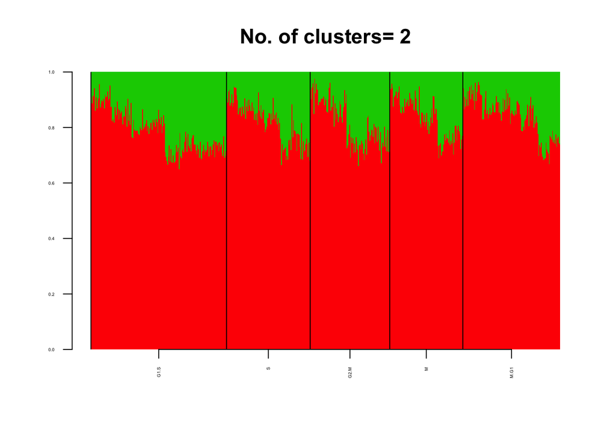

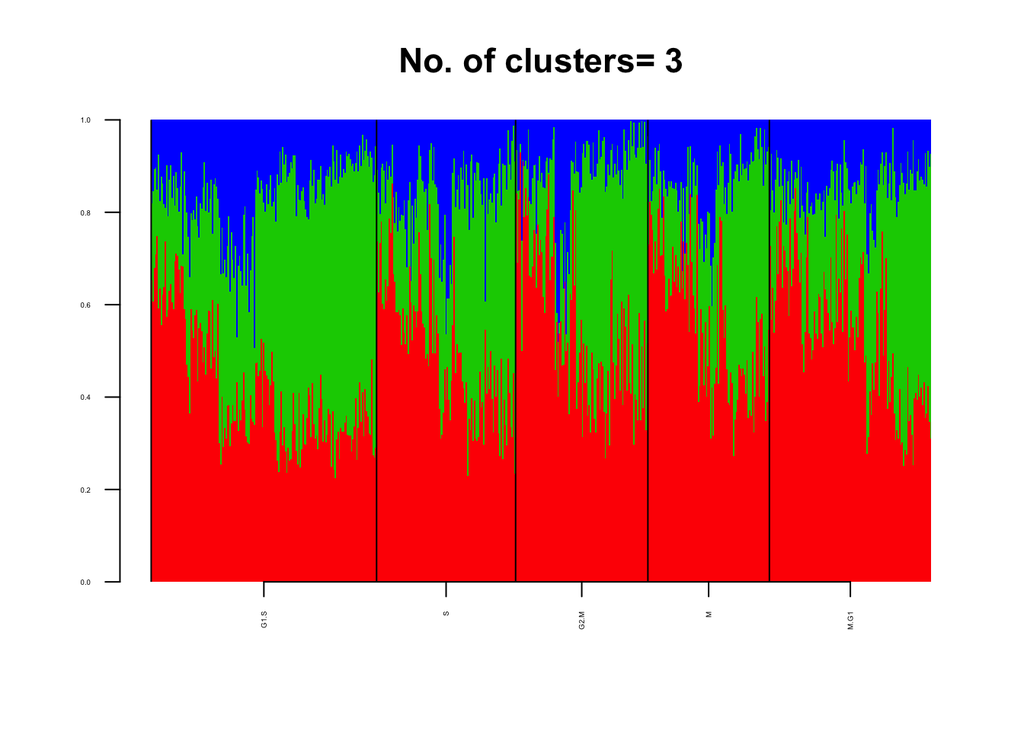

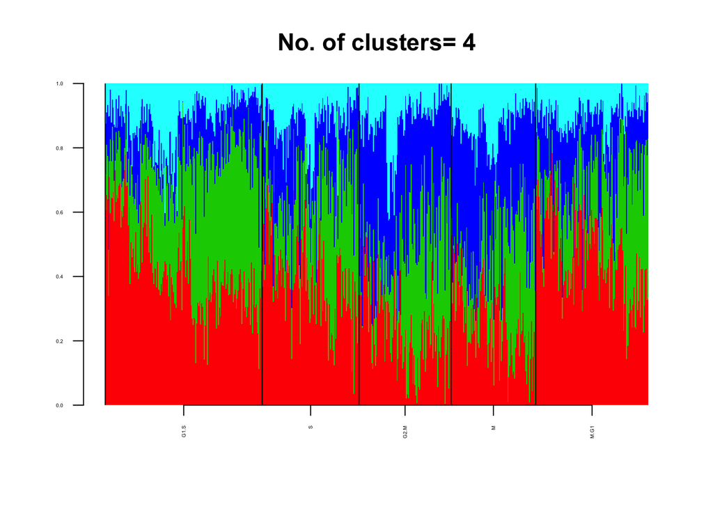

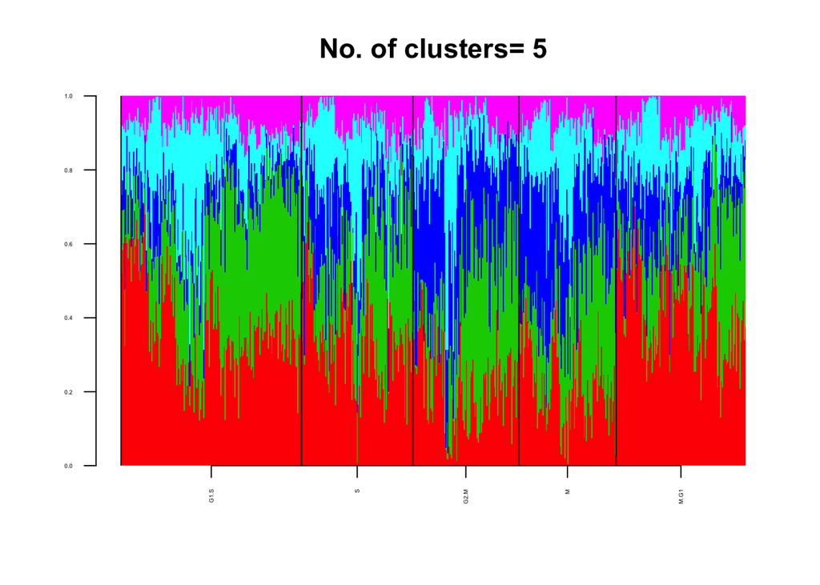

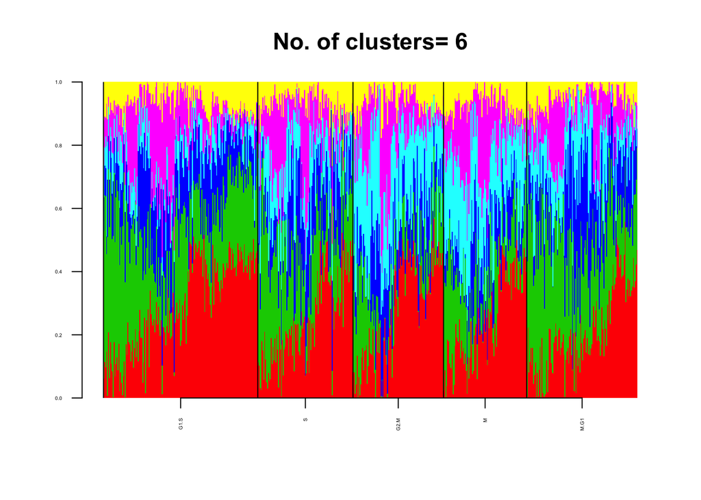

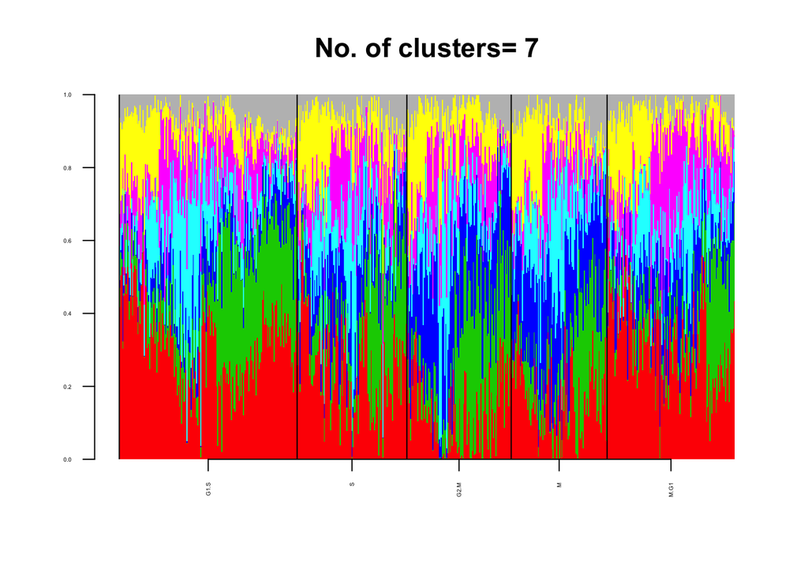

```r
nclust <- length(topics_list)
type_info <- cell_phase_vector

for (per_clust in 1:nclust) {
    topics_clust <- topics_list[[per_clust]]
    clust <- topics_clust$K
    docweights <- topics_clust$omega
    type_ordered <- type_info[order(type_info)]
    docweights_ordered <- docweights[order(type_info),]
    barplot( t(docweights_ordered),
             col = 2:(clust+1), axisnames = F,
             space = 0, border=NA,
             main = paste("No. of clusters=", clust), las = 1,
             ylim = c(0,1), cex.axis = 0.3, cex.main=1.4)
    labels <- match(unique(type_ordered), type_ordered)
    abline(v=labels-1)
    labels_low <- labels-1
    labels_up <- c(labels_low[2:length(labels_low)], dim(docweights_ordered)[1])
    mid_point <- labels_low +0.5*(labels_up-labels_low)
    axis(1, at = mid_point, unique(type_ordered), las = 2, cex.axis=0.3)
}
```

### t-SNE

We now implement t-SNE on the molecule counts based on the data on the cell cycle genes to see how the single cells cluster.

```r
if(file.exists("../rdas/clustering-cell-cycle-genes/tsne-maximum-normalized.rda")) {
    load("../rdas/clustering-cell-cycle-genes/tsne-maximum-normalized.rda")
} else {
    tsne_samples <- tsne(t(molecules_single_cell_cycle), 2)
    save(tsne_samples, file = "../rdas/clustering-cell-cycle-genes/tsne-maximum-normalized.rda")
}
```

Make tsne plots

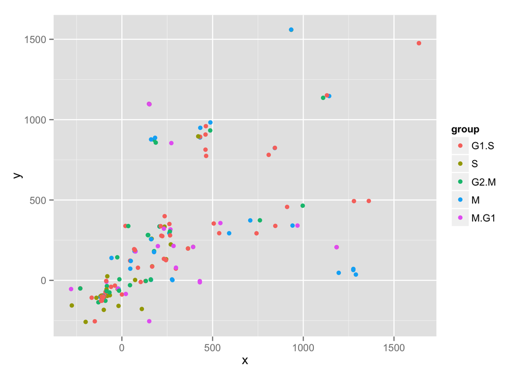

```r
ggplot(data = data.frame(x = tsne_samples[ ,1],
                         y = tsne_samples[ ,2],
                         group = cell_phase_vector),
       aes(x = x, y = y, colour = group)) +
    geom_point()
```

## Maximum absolute normalized value of cell cycle scores

From the admixture plot on the cell cycle genes, there seems to be a weak cell cycle specific effect indeed even for the cell cycle genes. We now focus on a different assignment scheme where instead of assigning the cell to the maximum normalized value, we assign it to the maximum absolute normalized value.

### Admixture model

Compute maximum absolute normalized value of cell cycle scores.

```r
cell_phase <- apply(ans_normed_normed, 1, function(x) {
                    colnames(cell_cycle_genes)[which.max(abs(x))]
                    })
assign_cell_phase <- data.frame(cell_phase)
cell_phase_vector <- as.vector(as.matrix(assign_cell_phase))
cell_phase_vector <- factor(cell_phase_vector,
                            levels = c("G1.S", "S", "G2.M", "M", "M.G1"))
```

Admixture models of 2 to 7 clusters.

```r
clust_vec <- 2:7
if(file.exists("../rdas/clustering-cell-cycle-genes/topics-maximum-normalized.rda")) {
    load("../rdas/clustering-cell-cycle-genes/topics-maximum-normalized.rda")
} else {
    topics_list <- lapply(clust_vec, function(per_clust) {
        topics(t(molecules_single_cell_cycle), K = per_clust)
        })
    names(topics_list) <- paste0("clust",clust_vec)
    save(topics_list, file = "../rdas/clustering-cell-cycle-genes/topics-maximum-normalized.rda")
}
```

Make structure plots with a new vector of `cell_phase_vector`.

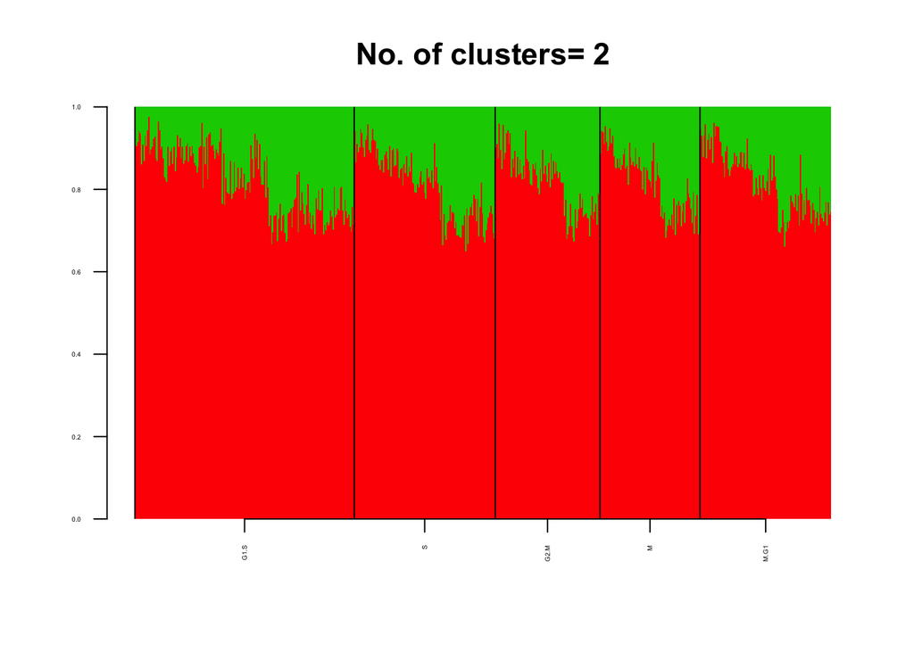

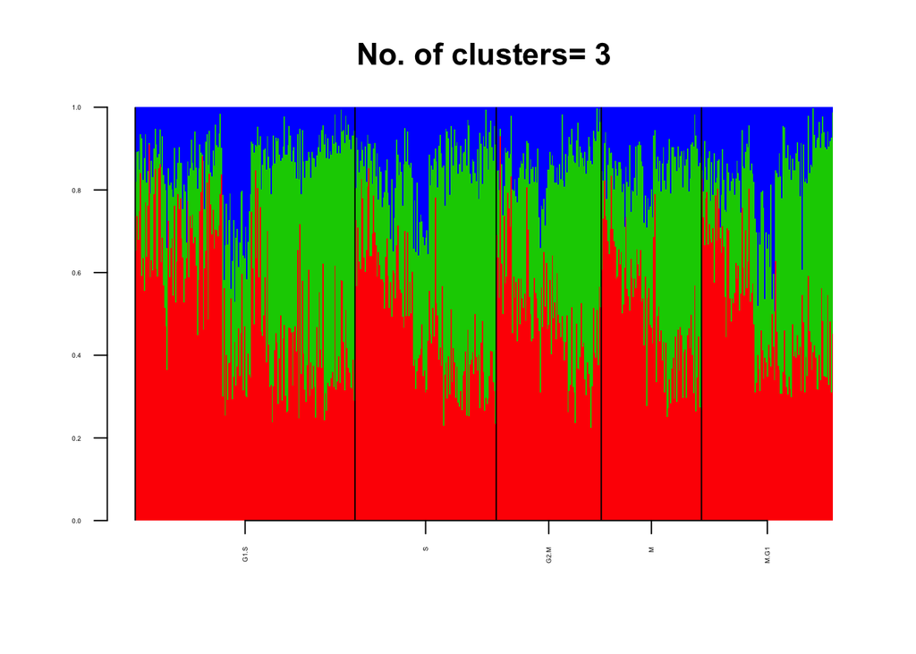

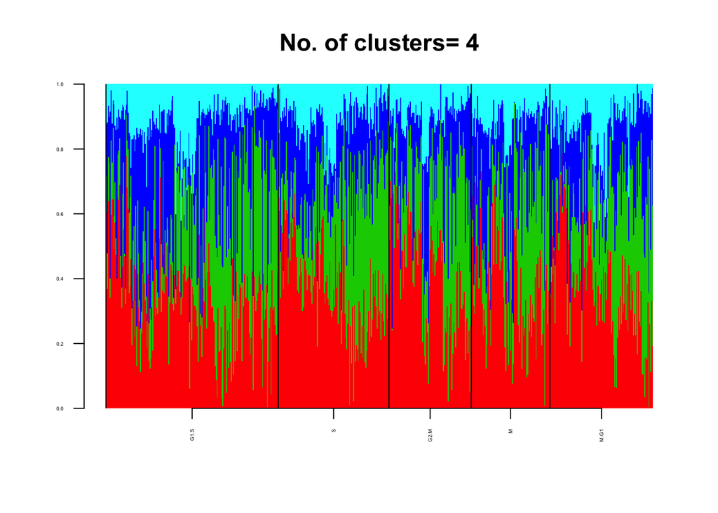

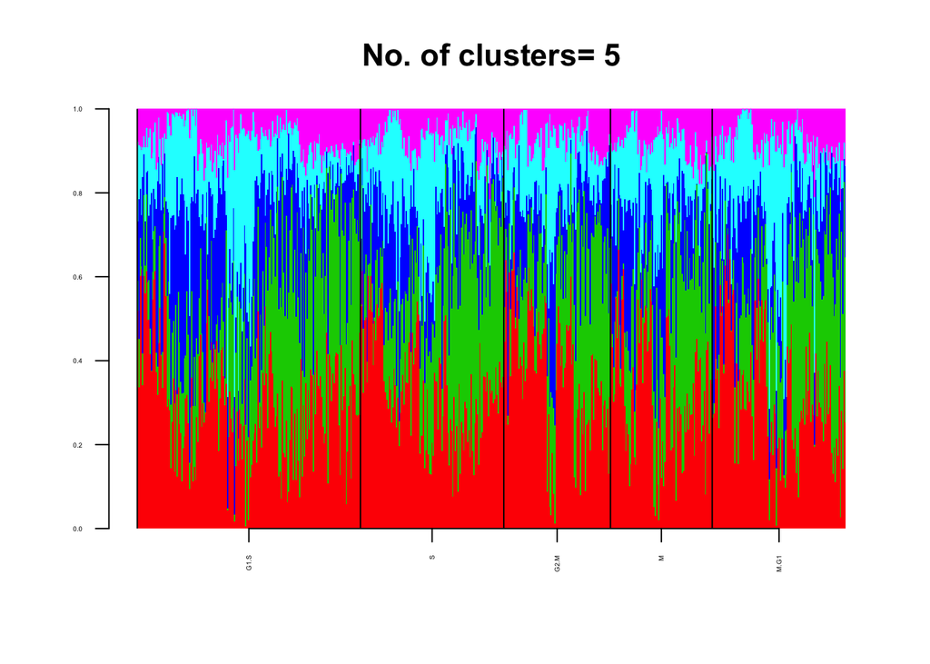

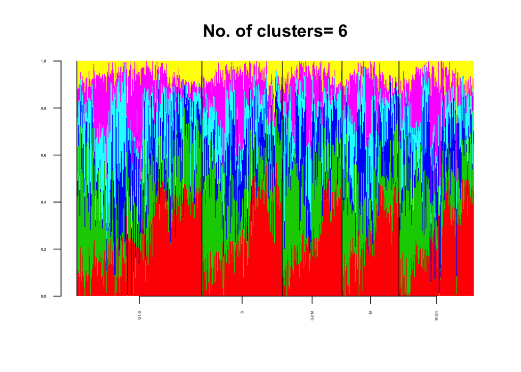

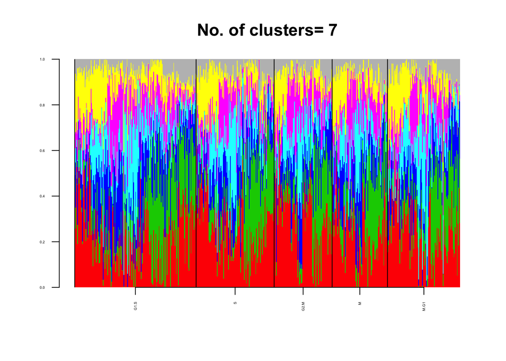

```r
nclust <- length(topics_list)
type_info <- cell_phase_vector

for (per_clust in 1:nclust) {
    topics_clust <- topics_list[[per_clust]]
    clust <- topics_clust$K
    docweights <- topics_clust$omega
    type_ordered <- type_info[order(type_info)]
    docweights_ordered <- docweights[order(type_info),]
    barplot( t(docweights_ordered),
             col = 2:(clust+1), axisnames = F,
             space = 0, border=NA,
             main = paste("No. of clusters=", clust), las = 1,
             ylim = c(0,1), cex.axis = 0.3, cex.main=1.4)
    labels <- match(unique(type_ordered), type_ordered)
    abline(v=labels-1)
    labels_low <- labels-1
    labels_up <- c(labels_low[2:length(labels_low)], dim(docweights_ordered)[1])
    mid_point <- labels_low +0.5*(labels_up-labels_low)
    axis(1, at = mid_point, unique(type_ordered), las = 2, cex.axis=0.3)
}
```

### t-SNE

Load t-SNE results.

```r
if(file.exists("../rdas/clustering-cell-cycle-genes/tsne-maximum-normalized.rda")) {
    load("../rdas/clustering-cell-cycle-genes/tsne-maximum-normalized.rda")
} else {
    tsne_samples <- tsne(t(molecules_single_cell_cycle), 2)
    save(tsne_samples, file = "../rdas/clustering-cell-cycle-genes/tsne-maximum-normalized.rda")
}
```

See how single cells cluster according to the new cell phase vector.

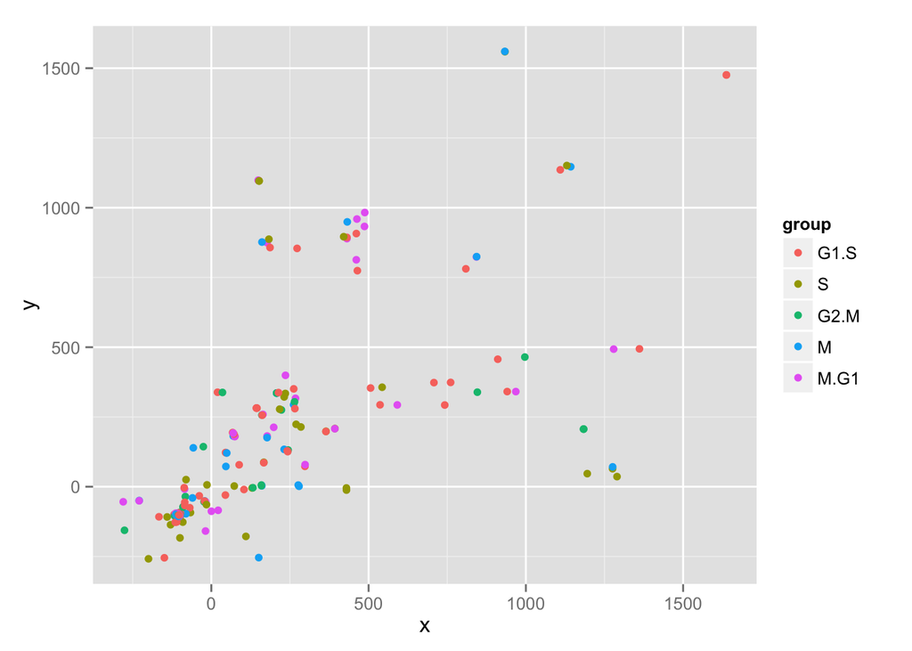

```r
ggplot(data = data.frame(x = tsne_samples[ ,1],
                         y = tsne_samples[ ,2],
                         group = cell_phase_vector),
       aes(x = x, y = y, colour = group)) +
    geom_point()
```